# ARF Conditional Density Dashboard

## Experiment 17

- **mtry**: 2
- **family**: truncnorm
- **finite_bounds**: local
- **num_trees**: 500
- **min_node_size**: 100
- **IAE**: 0.27

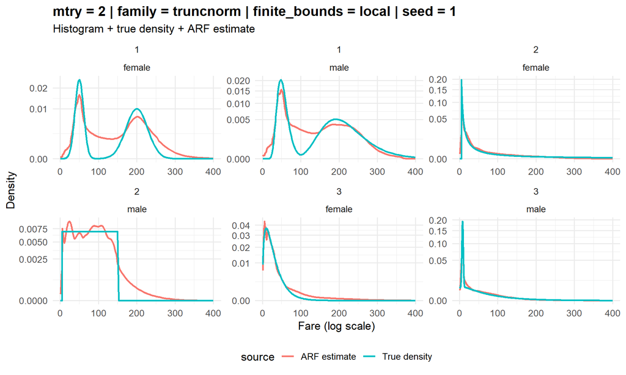

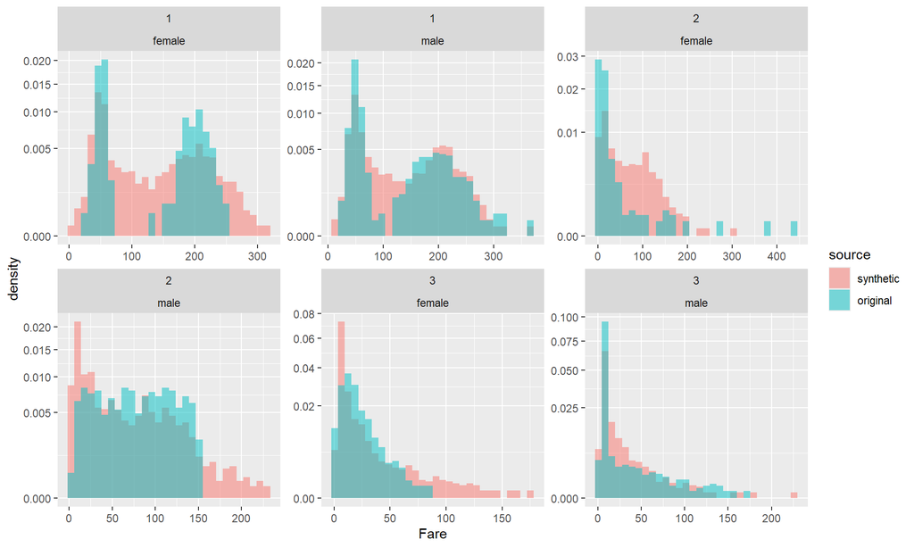

## Experiment 18

- **mtry**: 2
- **family**: truncnorm
- **finite_bounds**: local
- **num_trees**: 100
- **min_node_size**: 100
- **IAE**: 0.27

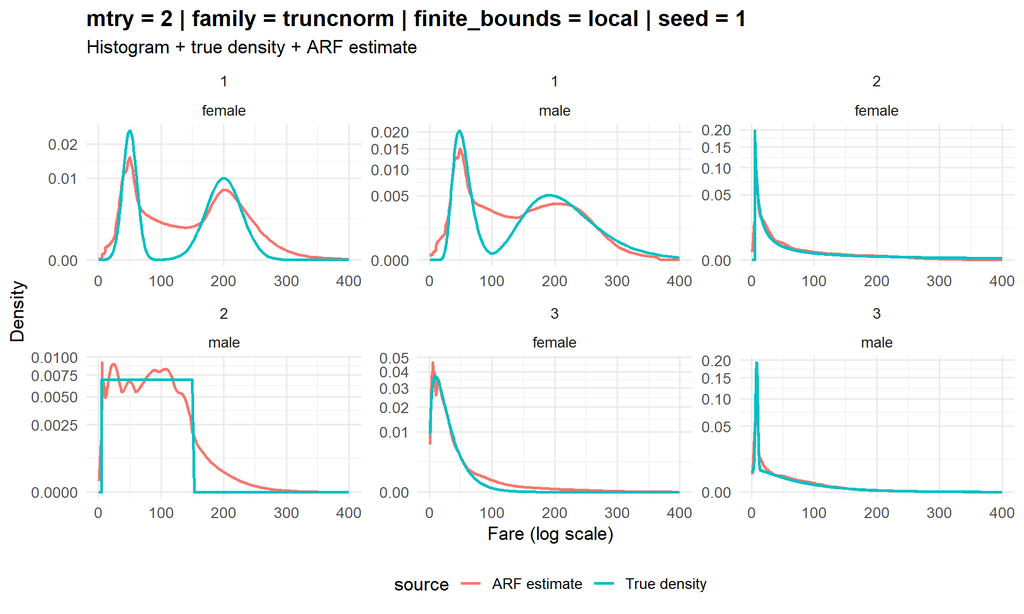

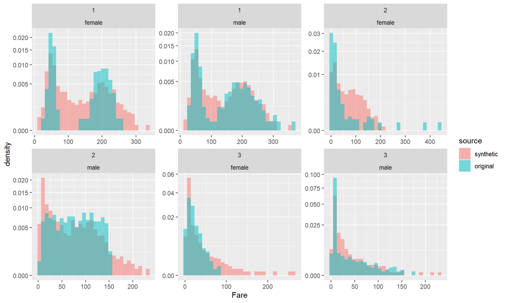

## Experiment 19

- **mtry**: 2
- **family**: truncnorm
- **finite_bounds**: no
- **num_trees**: 500
- **min_node_size**: 100
- **IAE**: 0.289

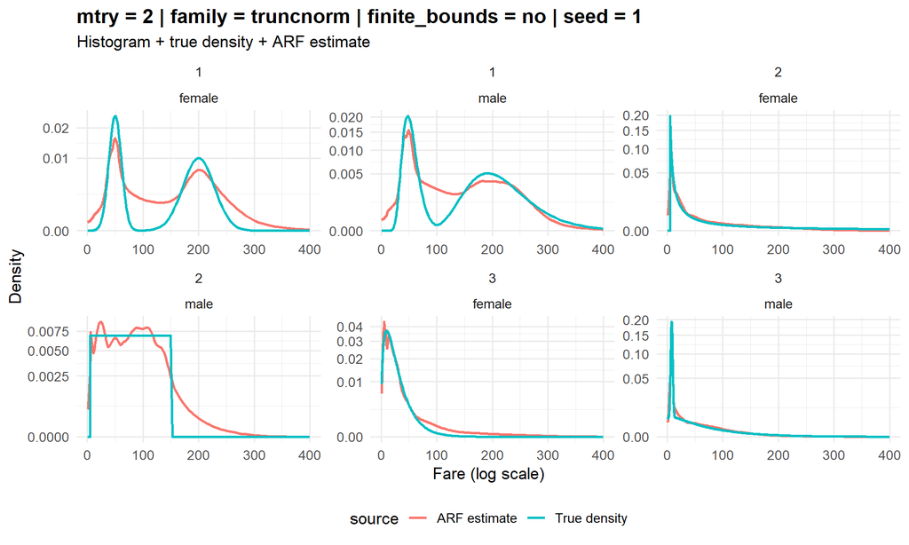

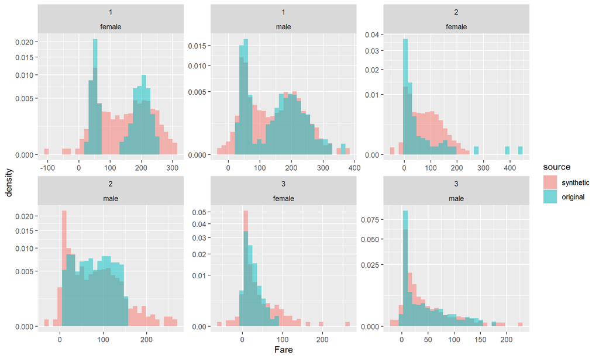

## Experiment 20

- **mtry**: 2
- **family**: truncnorm
- **finite_bounds**: no
- **num_trees**: 100
- **min_node_size**: 100
- **IAE**: 0.285

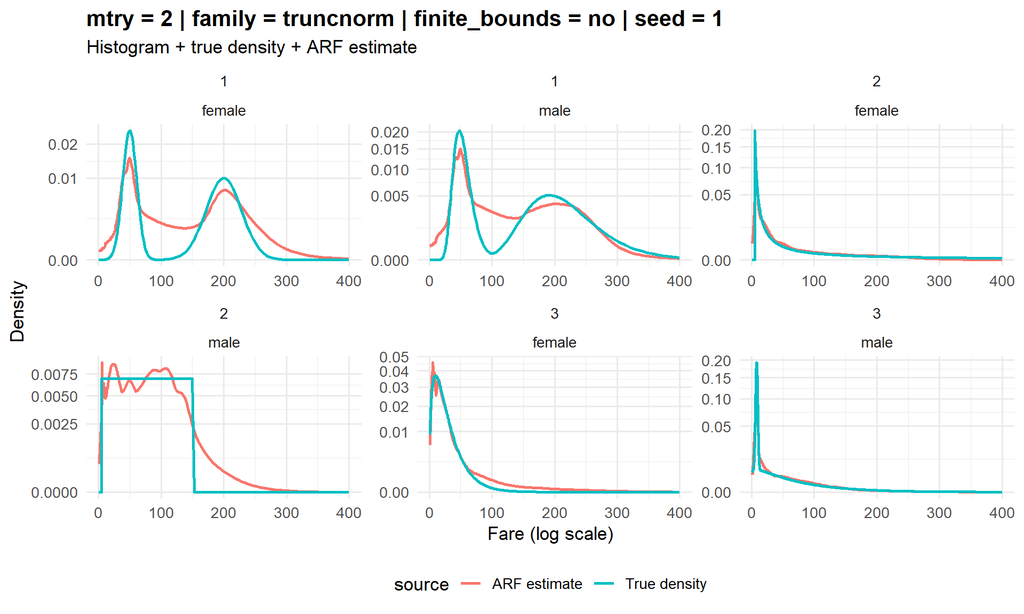

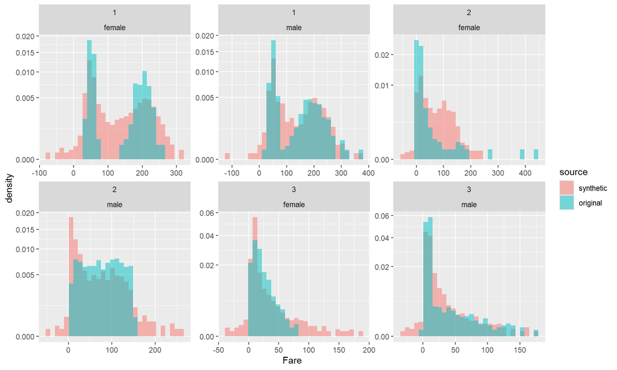

## Experiment 21

- **mtry**: 2
- **family**: unif
- **finite_bounds**: local
- **num_trees**: 500
- **min_node_size**: 20
- **IAE**: 0.363

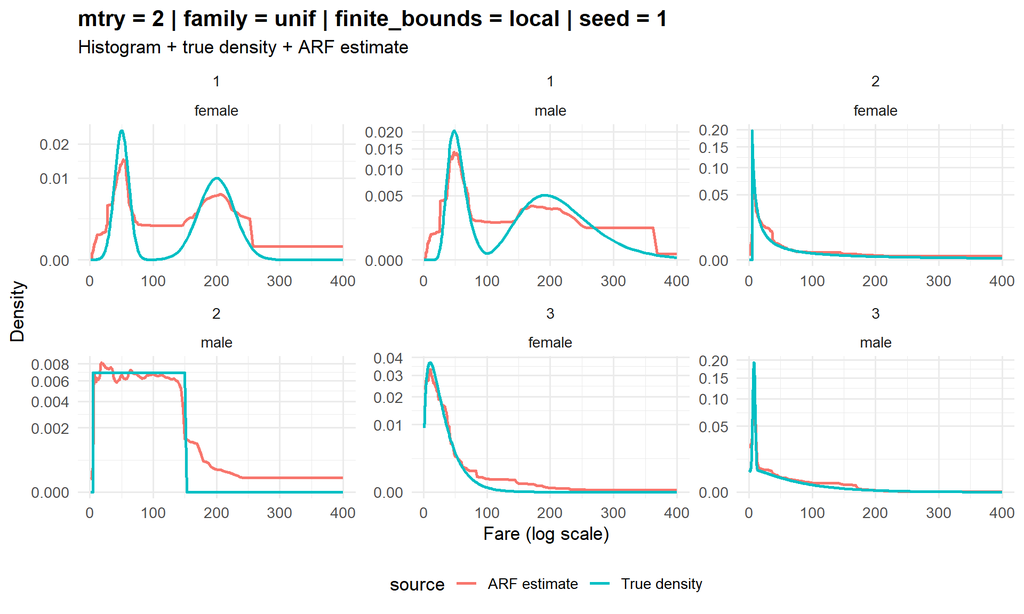

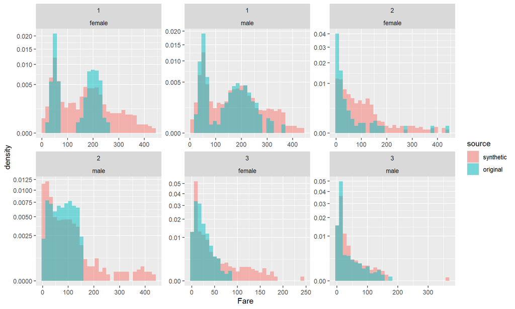

## Experiment 22

- **mtry**: 2
- **family**: unif
- **finite_bounds**: no
- **num_trees**: 500
- **min_node_size**: 20
- **IAE**: 0.363

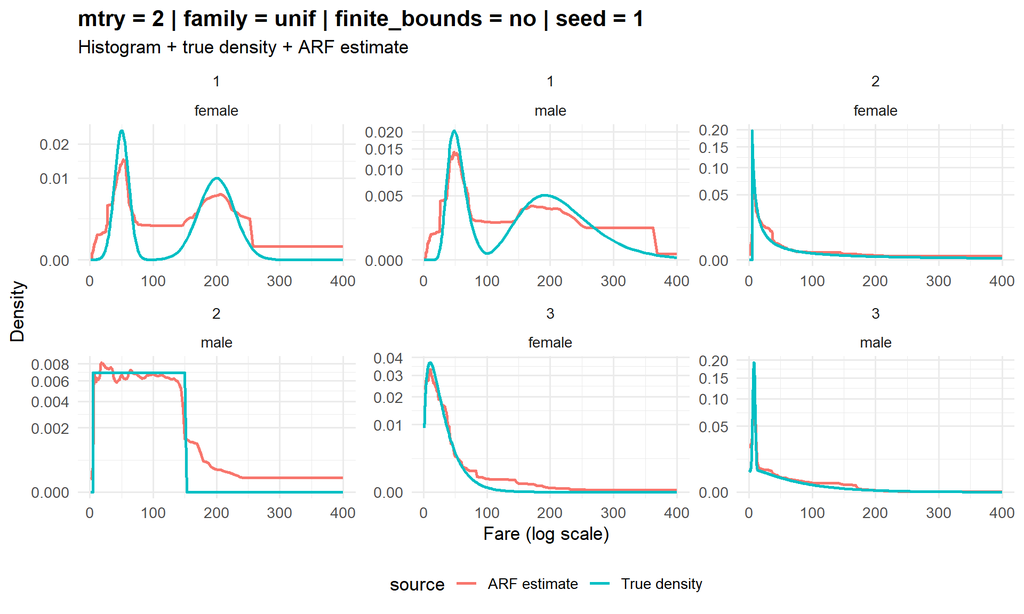

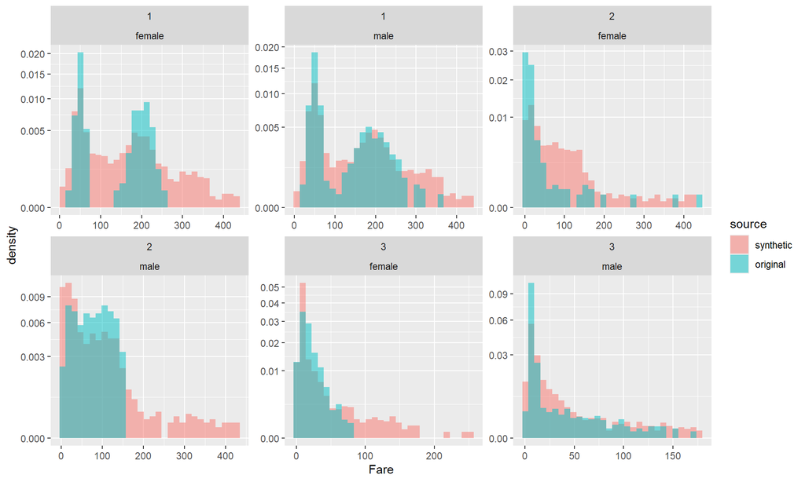

## Experiment 23

- **mtry**: 2
- **family**: unif
- **finite_bounds**: local
- **num_trees**: 100
- **min_node_size**: 20
- **IAE**: 0.378

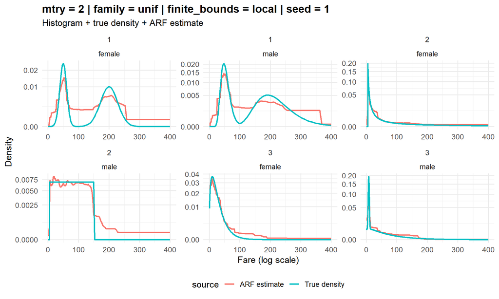

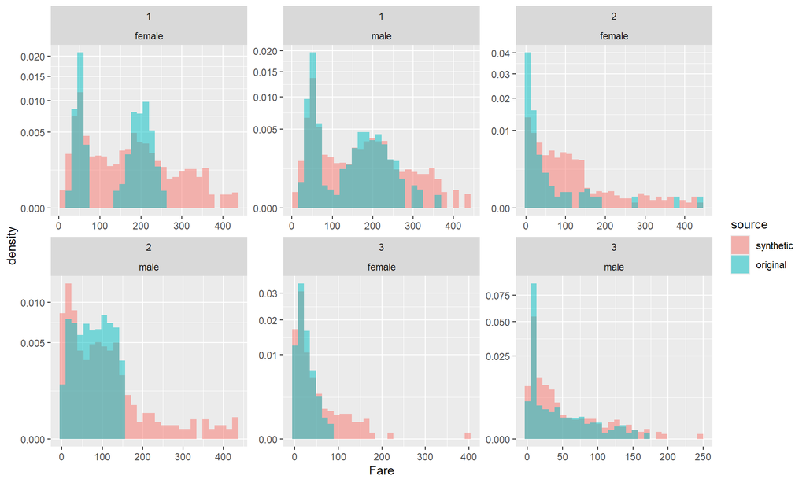

## Experiment 24

- **mtry**: 2
- **family**: unif
- **finite_bounds**: no
- **num_trees**: 100
- **min_node_size**: 20
- **IAE**: 0.378

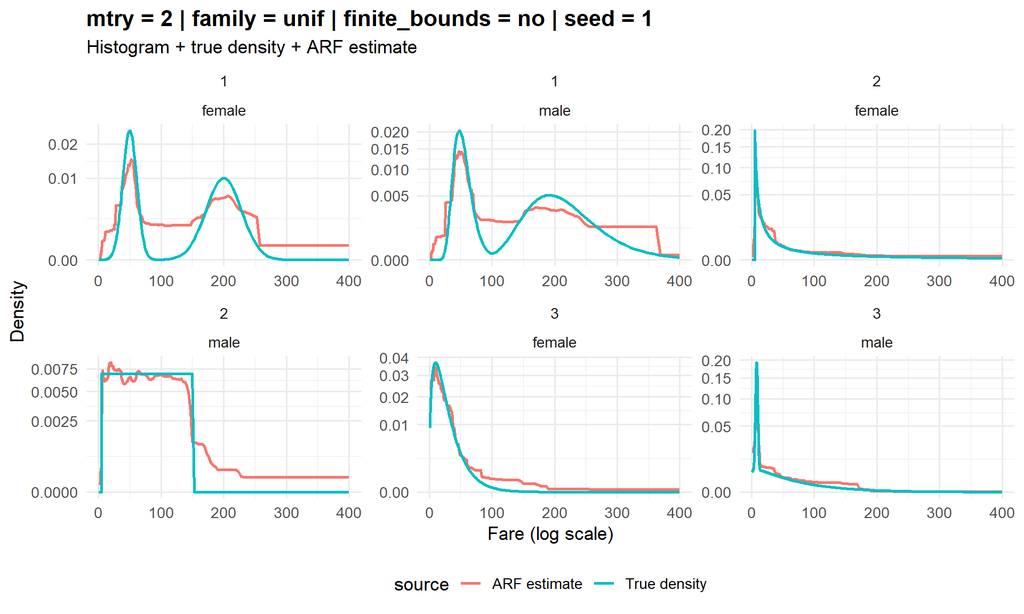

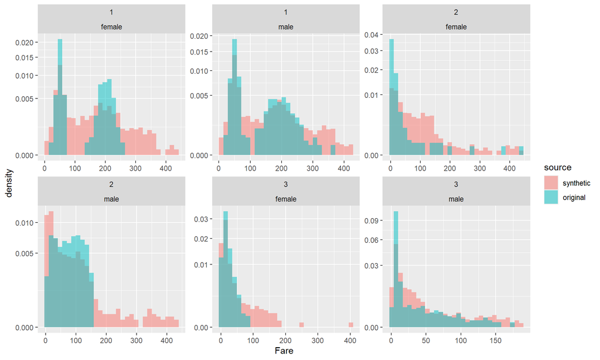

## Experiment 25

- **mtry**: 3
- **family**: unif
- **finite_bounds**: local
- **num_trees**: 500
- **min_node_size**: 100
- **IAE**: 0.337

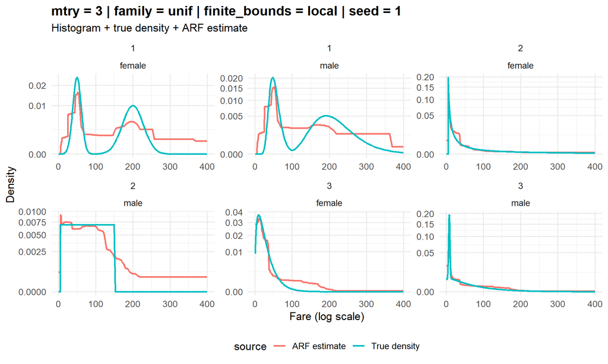

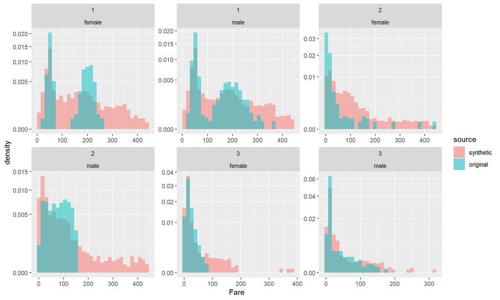

## Experiment 26

- **mtry**: 3
- **family**: unif
- **finite_bounds**: no
- **num_trees**: 500
- **min_node_size**: 100
- **IAE**: 0.337

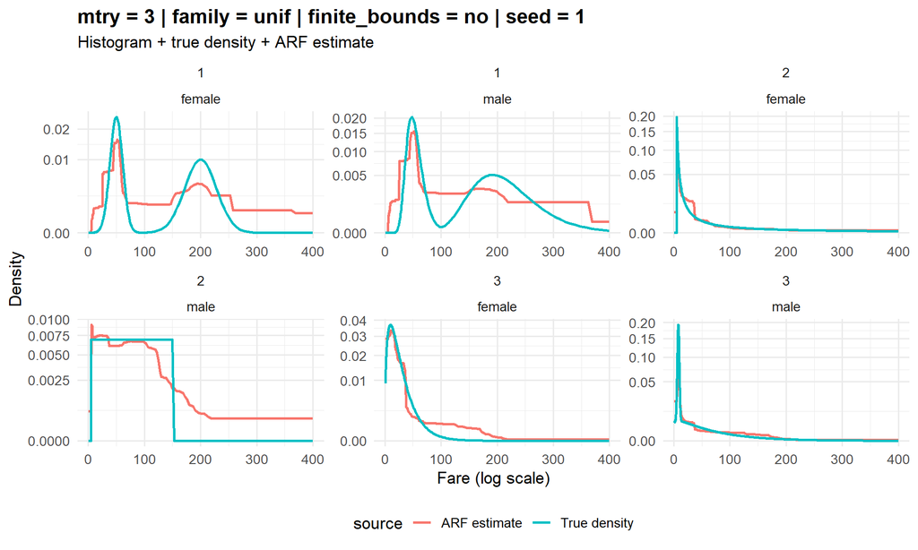

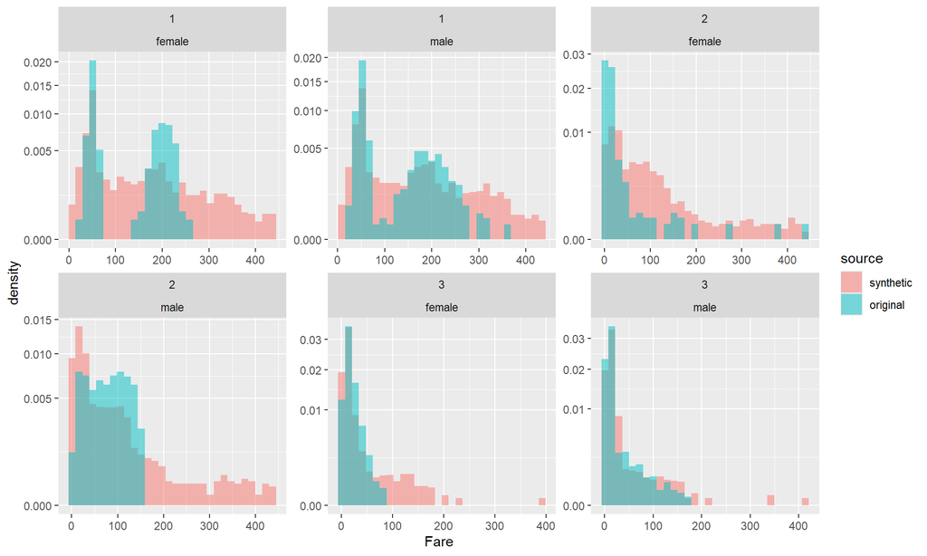

## Experiment 27

- **mtry**: 3
- **family**: unif
- **finite_bounds**: local
- **num_trees**: 100
- **min_node_size**: 100
- **IAE**: 0.331

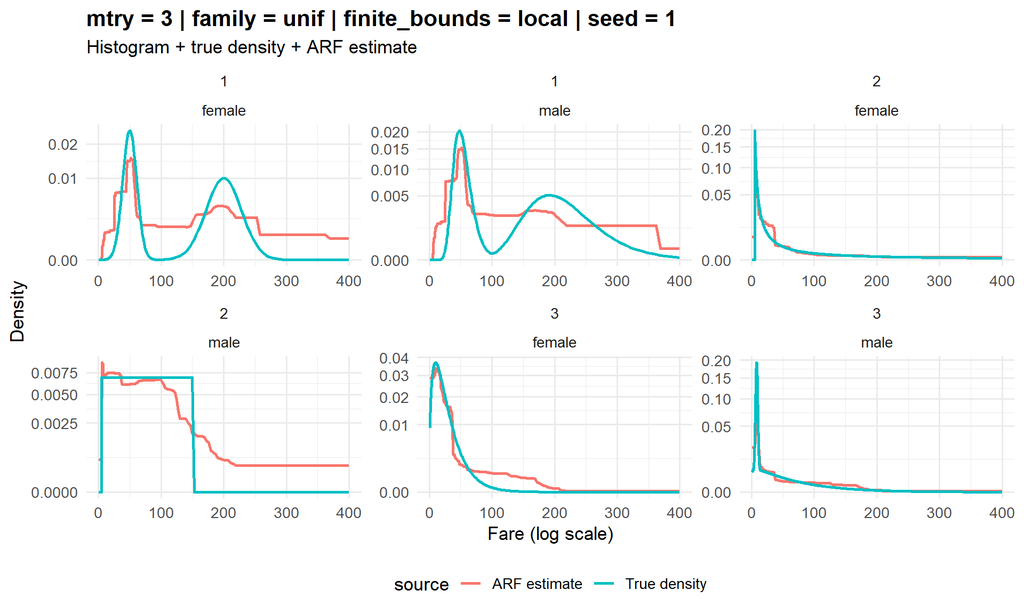

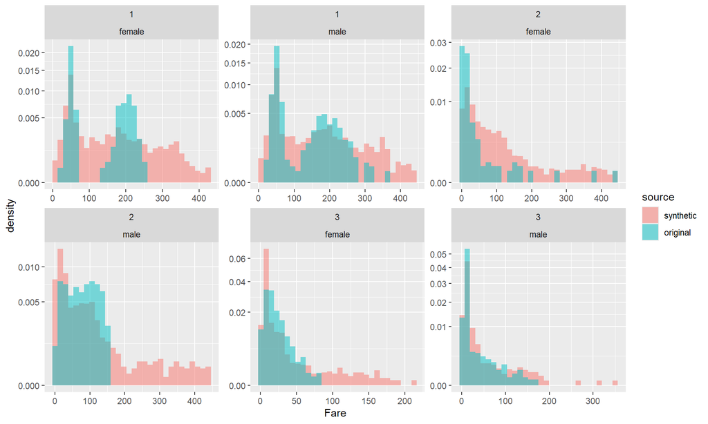

## Experiment 28

- **mtry**: 3
- **family**: unif
- **finite_bounds**: no
- **num_trees**: 100
- **min_node_size**: 100
- **IAE**: 0.331

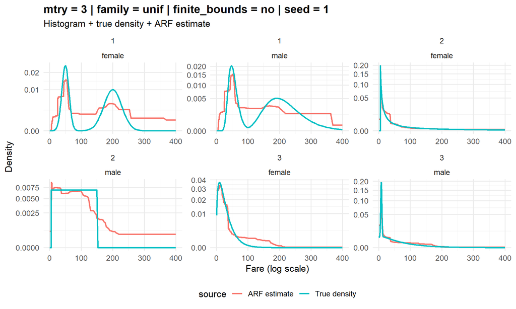

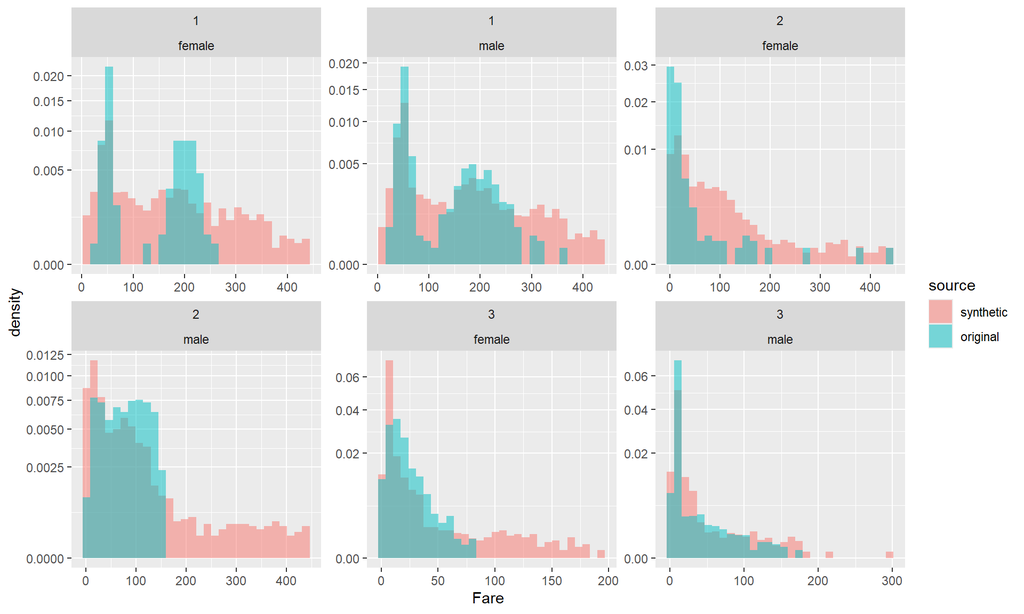

## Experiment 29

- **mtry**: 2
- **family**: unif
- **finite_bounds**: local
- **num_trees**: 500
- **min_node_size**: 100
- **IAE**: 0.441

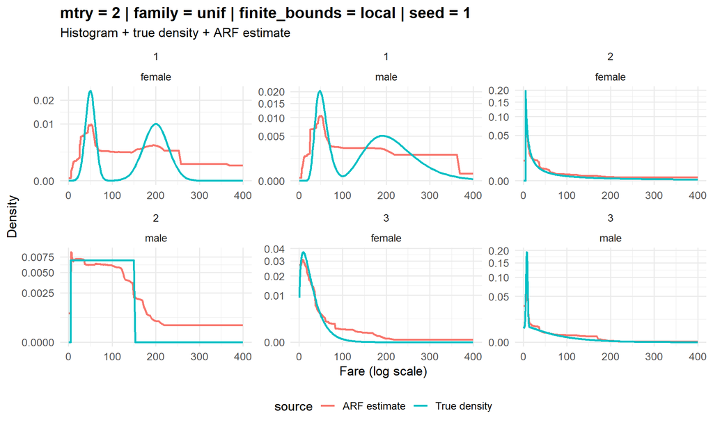

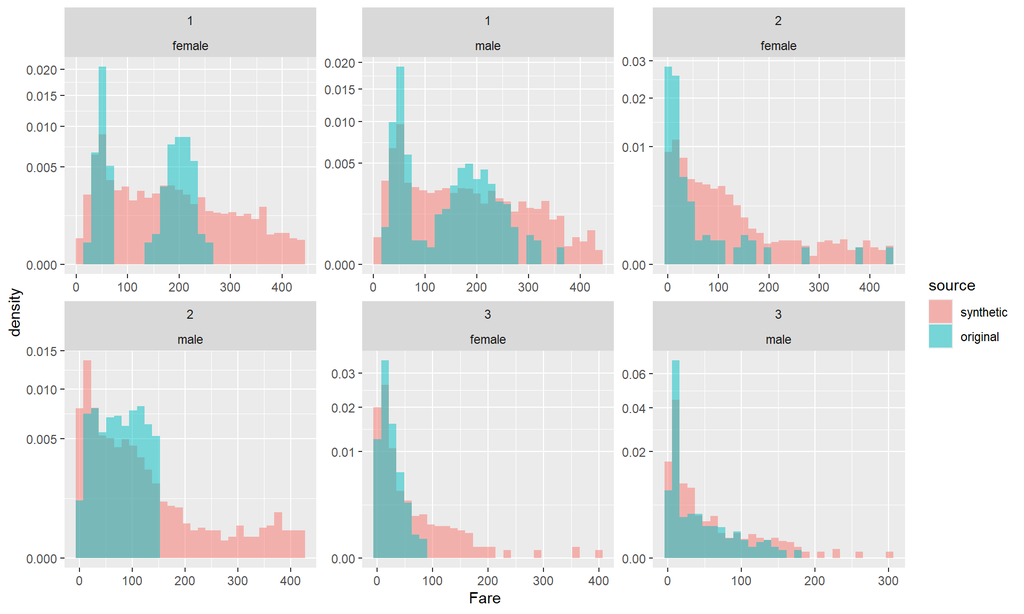

## Experiment 30

- **mtry**: 2
- **family**: unif
- **finite_bounds**: no
- **num_trees**: 500
- **min_node_size**: 100
- **IAE**: 0.441

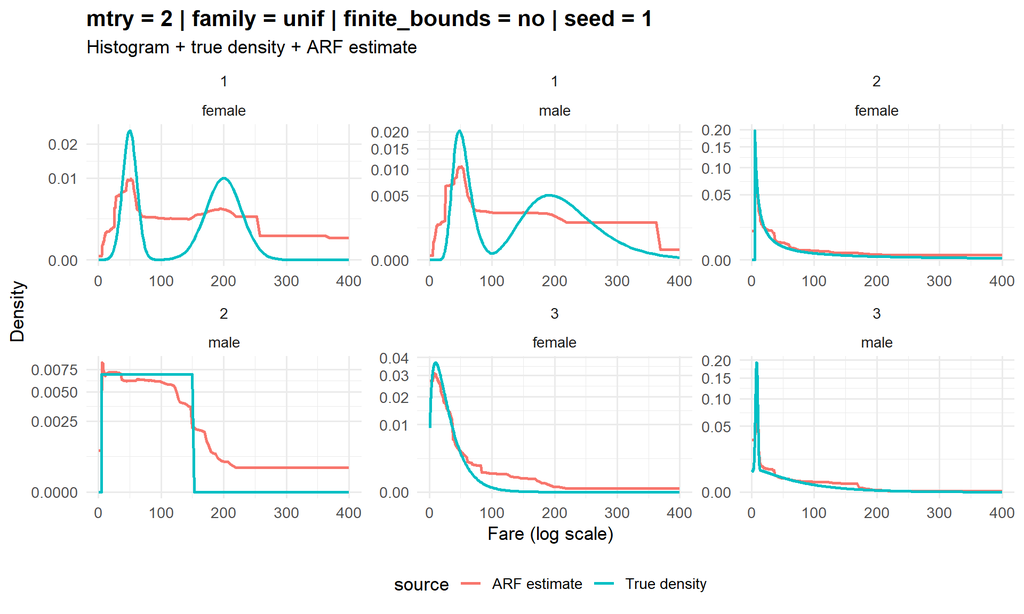

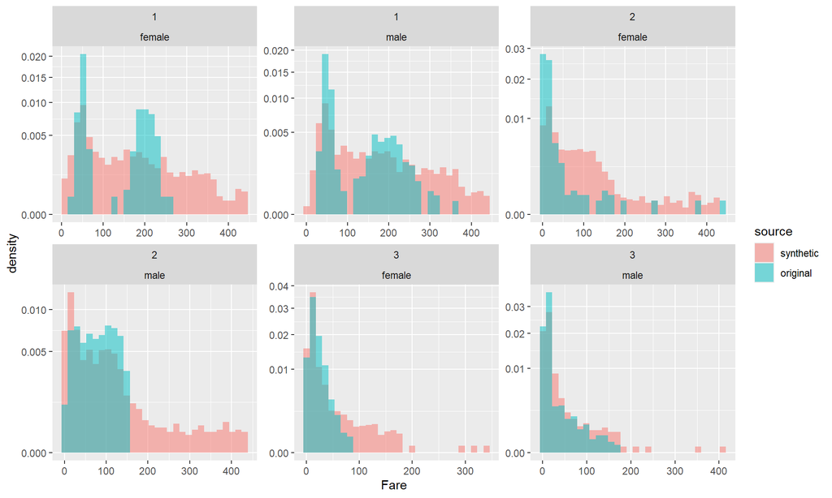

## Experiment 31

- **mtry**: 2
- **family**: unif
- **finite_bounds**: local
- **num_trees**: 100
- **min_node_size**: 100
- **IAE**: 0.421

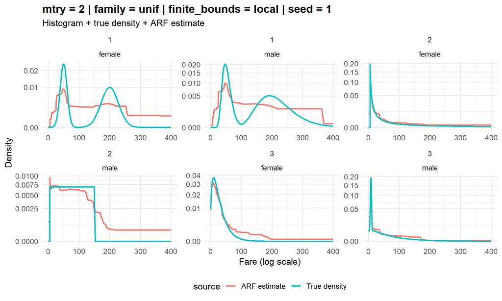

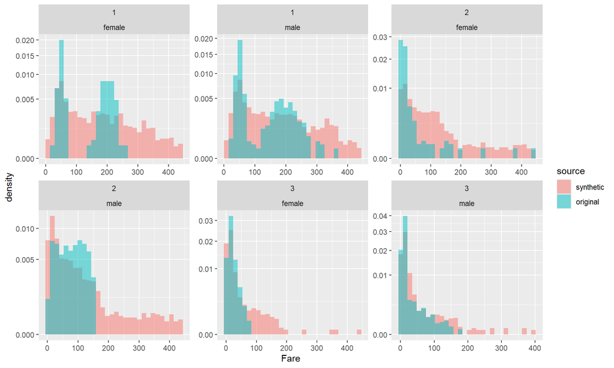

## Experiment 32

- **mtry**: 2
- **family**: unif
- **finite_bounds**: no
- **num_trees**: 100
- **min_node_size**: 100
- **IAE**: 0.421

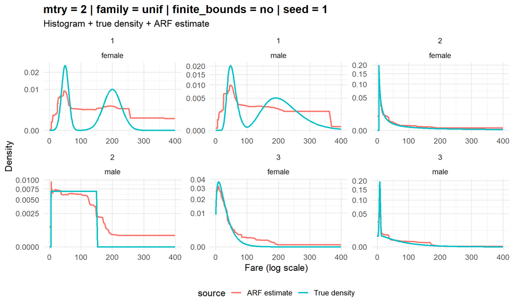

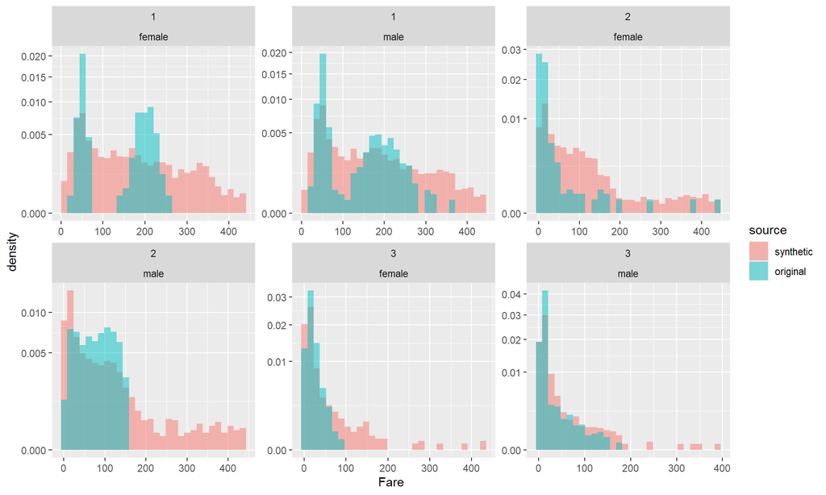

## Experiment 33

- **mtry**: 1
- **family**: truncnorm
- **finite_bounds**: no
- **num_trees**: 500
- **min_node_size**: 100
- **IAE**: 0.697

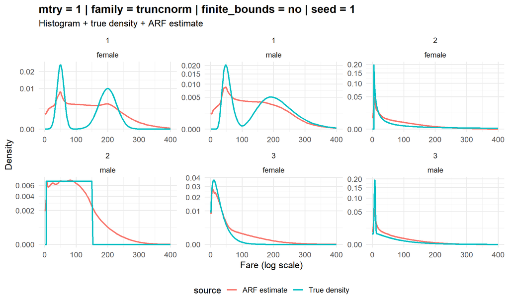

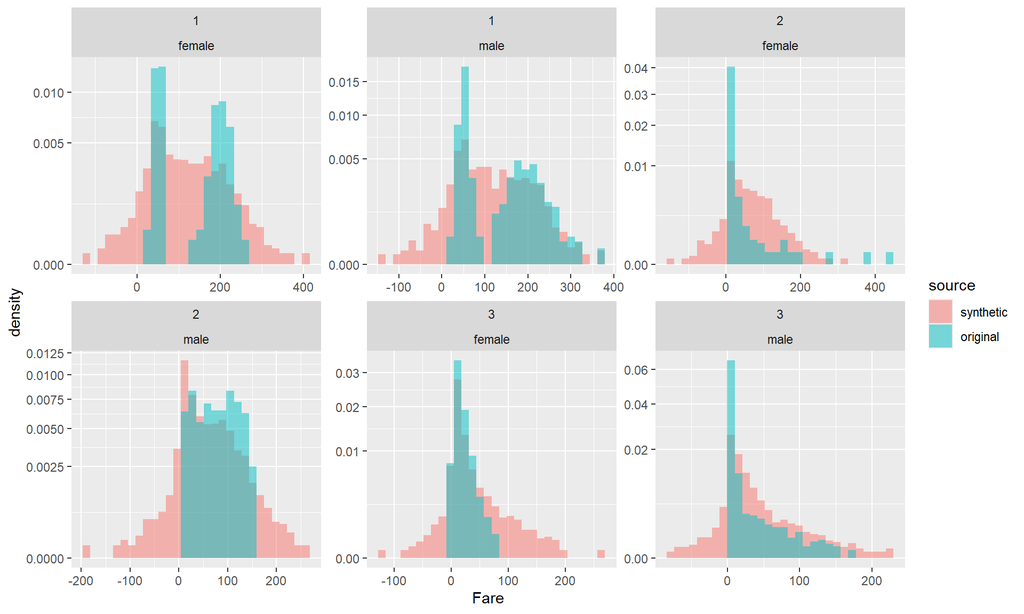

## Experiment 34

- **mtry**: 1
- **family**: truncnorm
- **finite_bounds**: no
- **num_trees**: 100
- **min_node_size**: 100
- **IAE**: 0.693

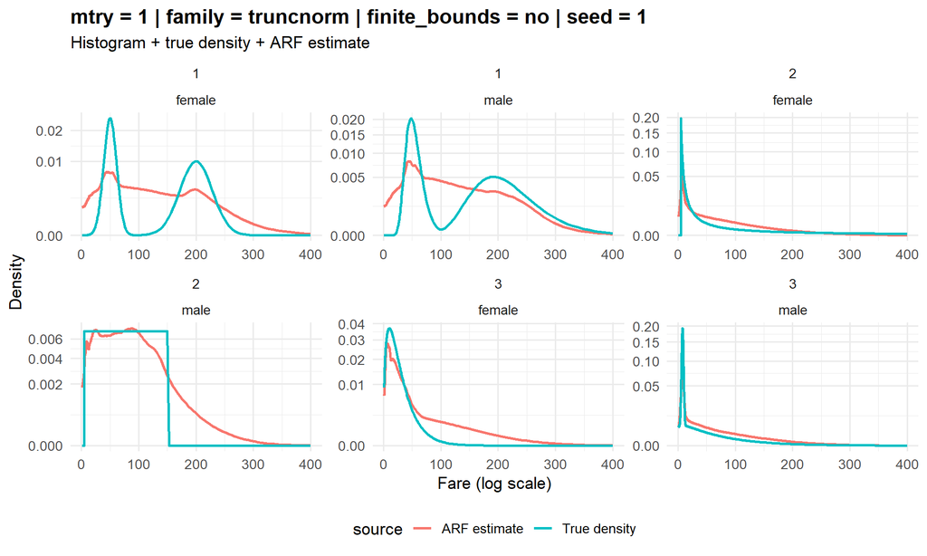

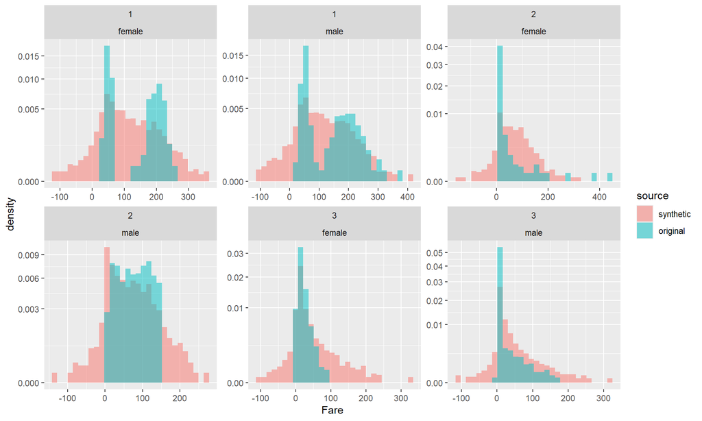

## Experiment 35

- **mtry**: 1
- **family**: truncnorm
- **finite_bounds**: local
- **num_trees**: 500
- **min_node_size**: 100
- **IAE**: 0.711

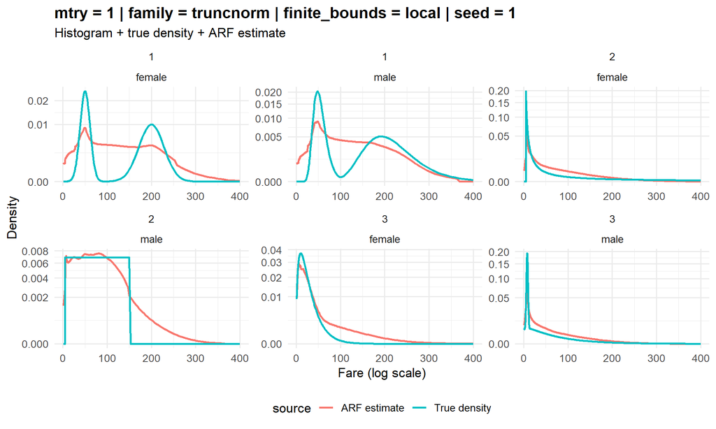

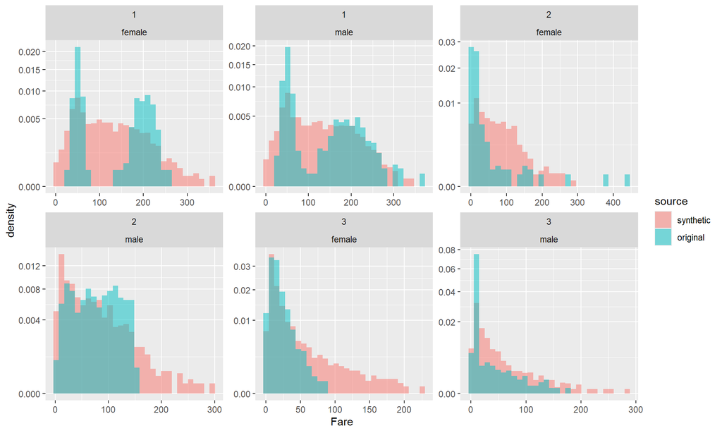

## Experiment 36

- **mtry**: 1
- **family**: truncnorm
- **finite_bounds**: local
- **num_trees**: 100
- **min_node_size**: 100
- **IAE**: 0.733

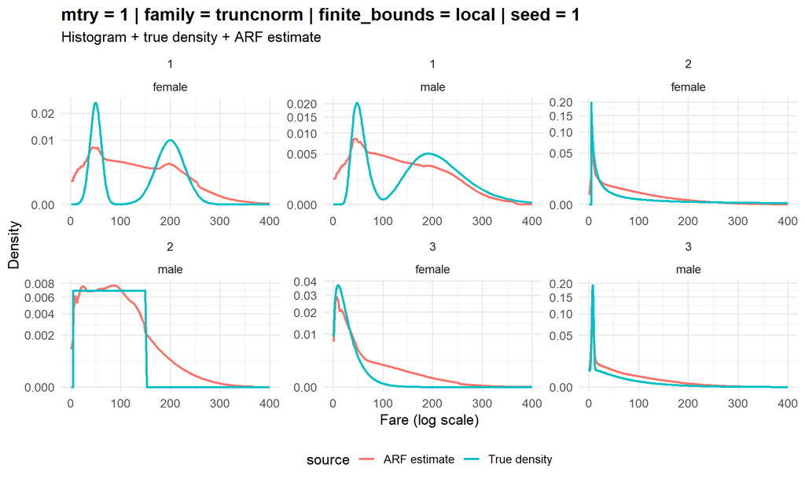

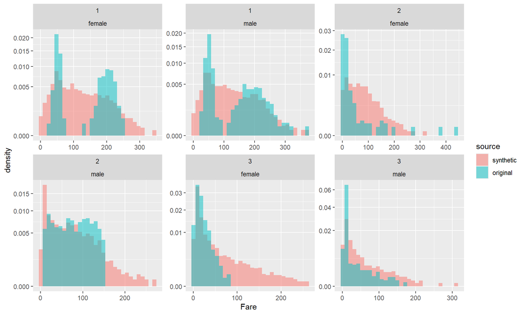

## Experiment 37

- **mtry**: 1
- **family**: truncnorm
- **finite_bounds**: no
- **num_trees**: 500
- **min_node_size**: 20
- **IAE**: 0.729

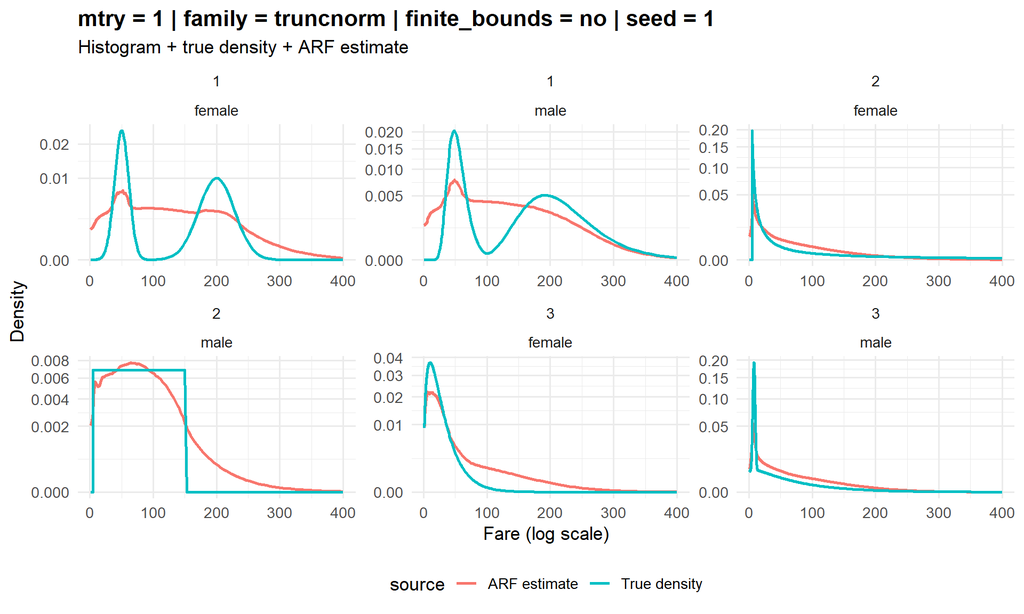

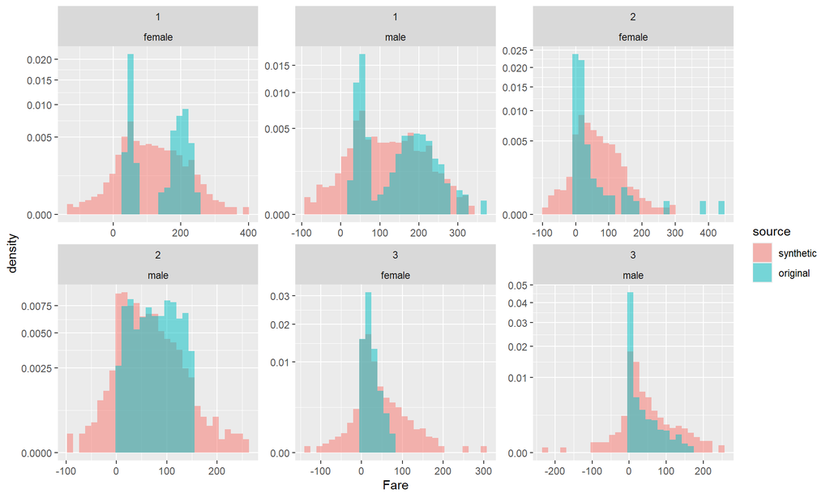

## Experiment 38

- **mtry**: 1
- **family**: truncnorm
- **finite_bounds**: local
- **num_trees**: 500
- **min_node_size**: 20
- **IAE**: 0.748

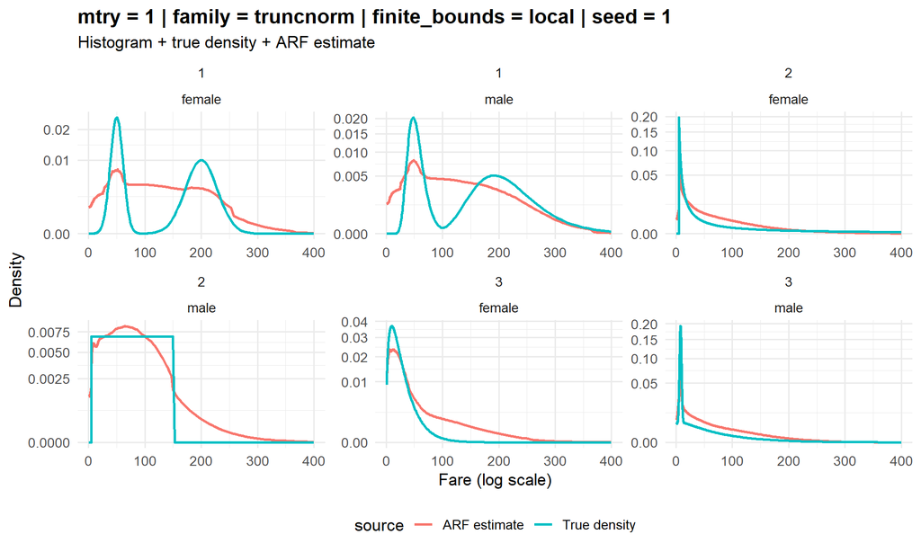

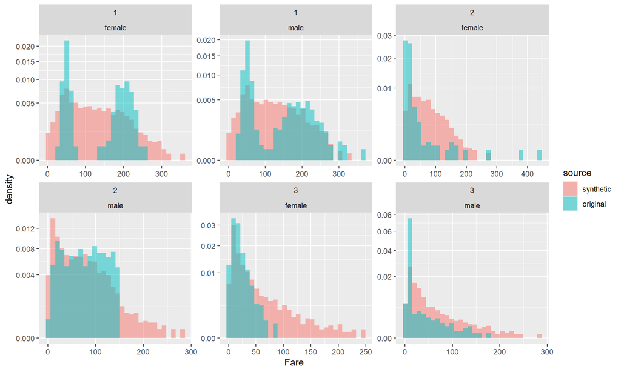

## Experiment 39

- **mtry**: 1
- **family**: truncnorm
- **finite_bounds**: no
- **num_trees**: 100
- **min_node_size**: 20
- **IAE**: 0.805

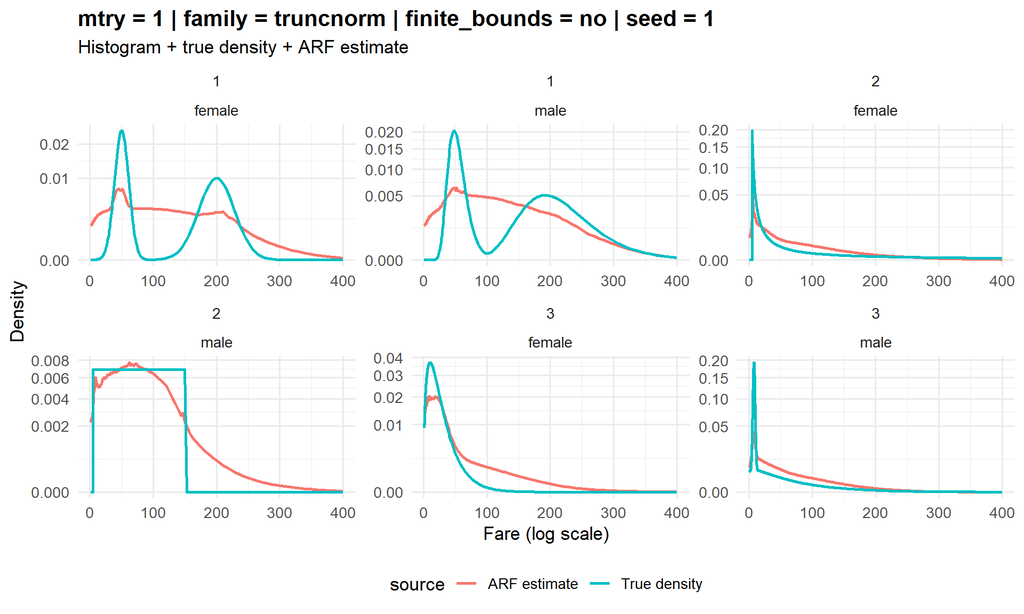

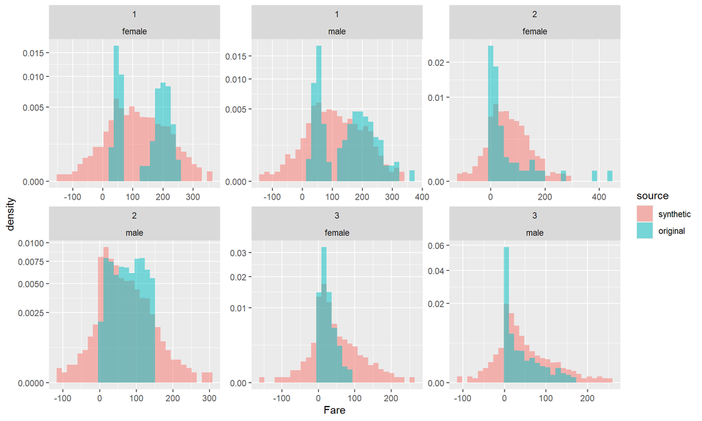

## Experiment 40

- **mtry**: 1
- **family**: truncnorm
- **finite_bounds**: local
- **num_trees**: 100
- **min_node_size**: 20
- **IAE**: 0.835

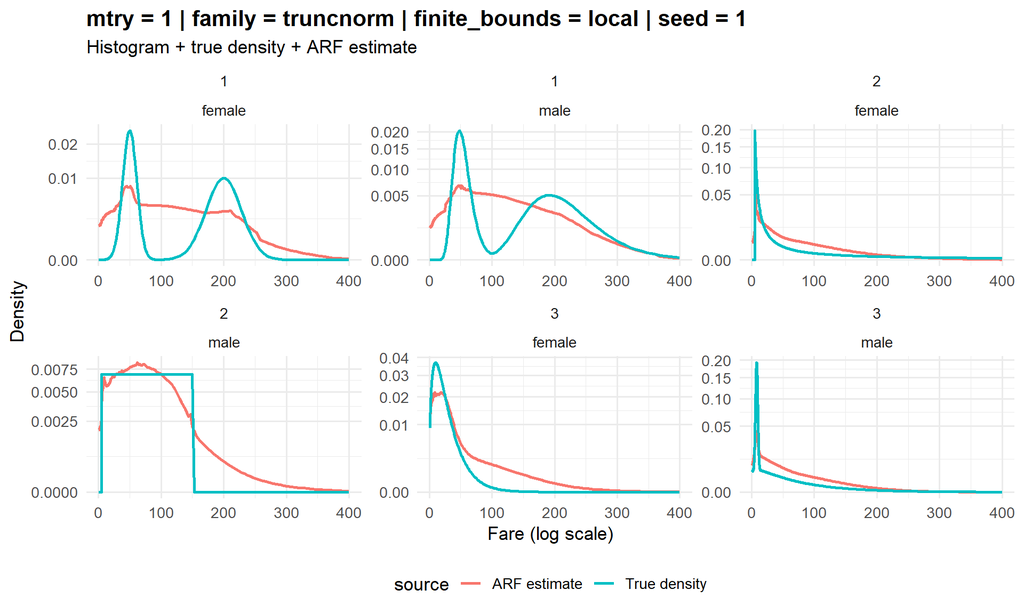

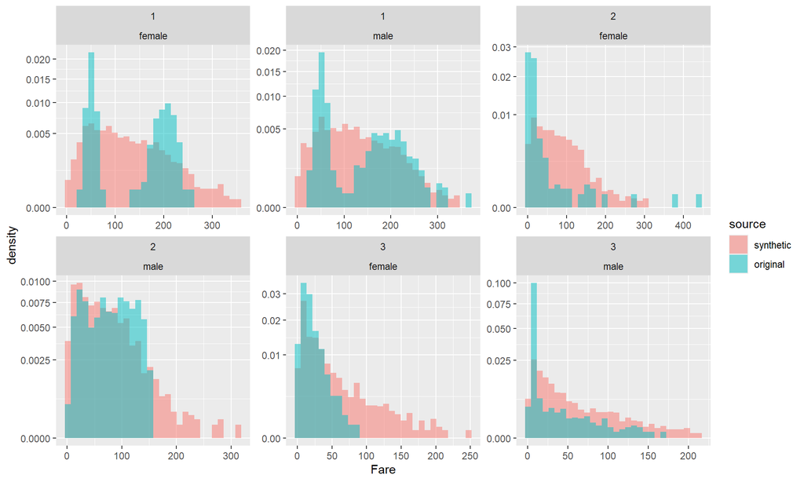

## Experiment 41

- **mtry**: 1
- **family**: unif
- **finite_bounds**: local
- **num_trees**: 100
- **min_node_size**: 100
- **IAE**: 0.876

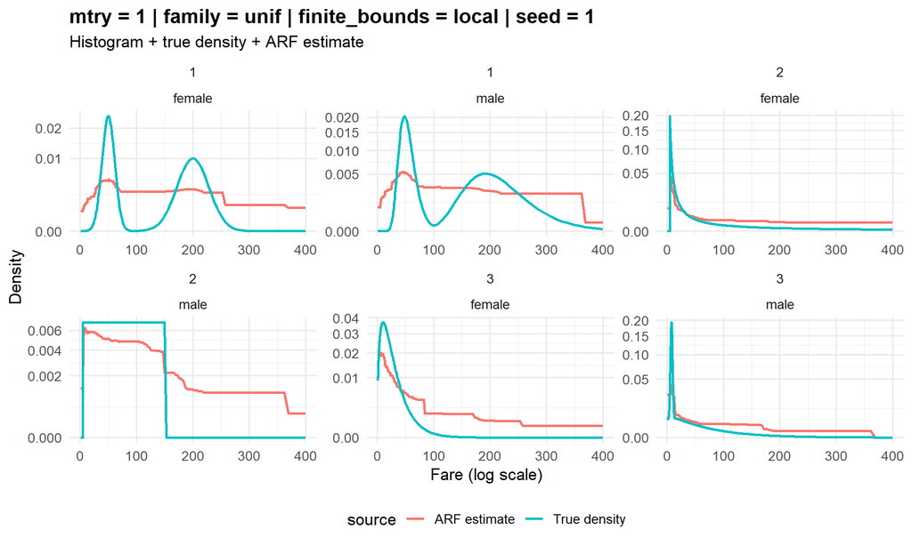

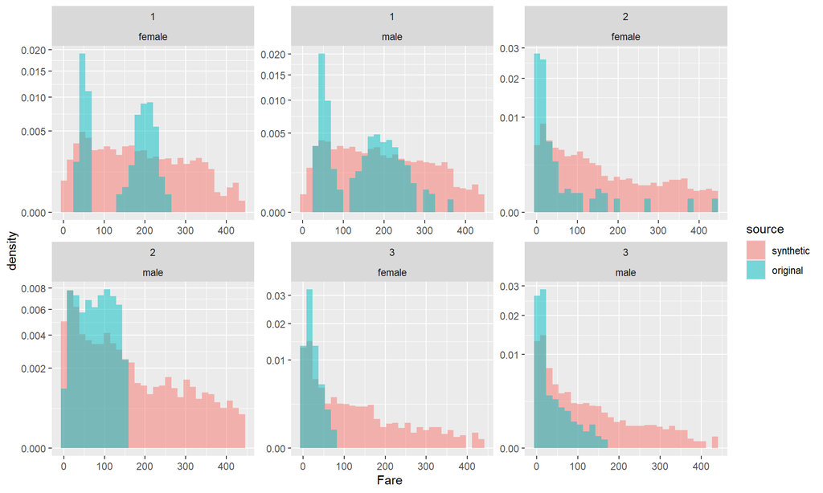

## Experiment 42

- **mtry**: 1
- **family**: unif
- **finite_bounds**: no
- **num_trees**: 100
- **min_node_size**: 100
- **IAE**: 0.876

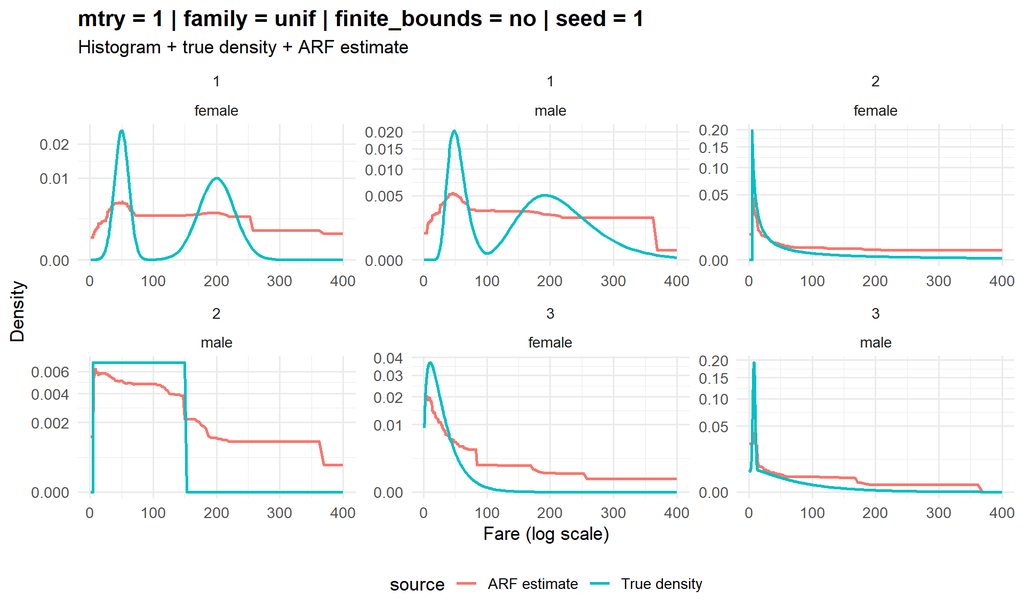

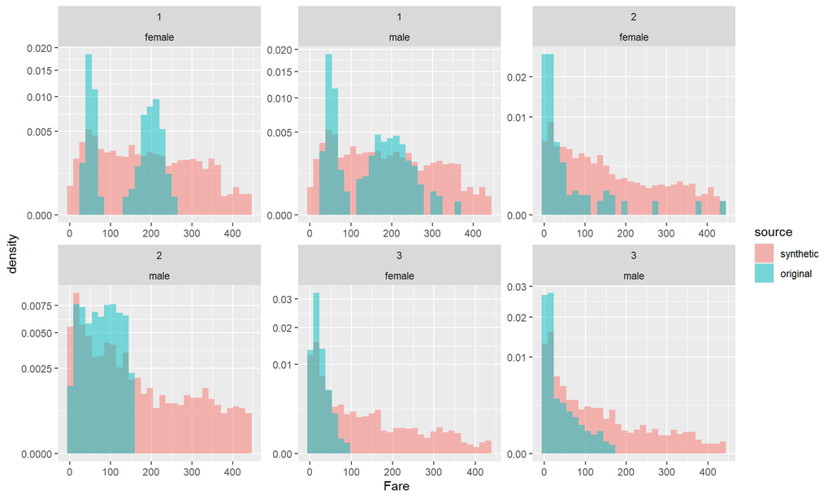

## Experiment 43

- **mtry**: 1
- **family**: unif
- **finite_bounds**: local
- **num_trees**: 500
- **min_node_size**: 20
- **IAE**: 0.897

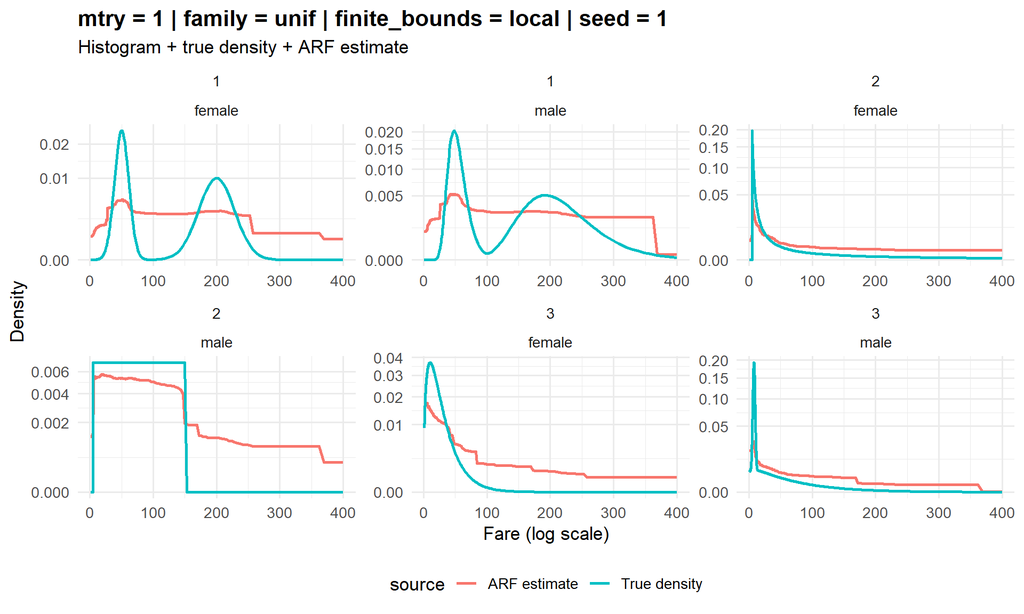

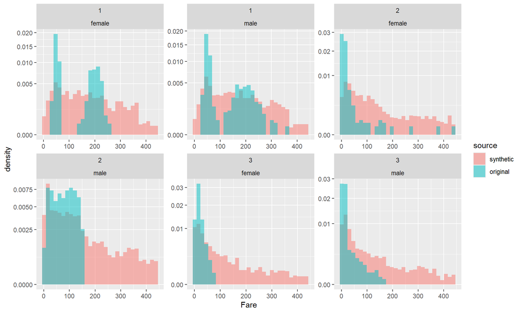

## Experiment 44

- **mtry**: 1
- **family**: unif
- **finite_bounds**: no
- **num_trees**: 500
- **min_node_size**: 20
- **IAE**: 0.897

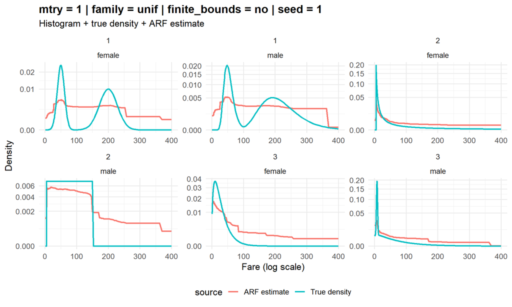

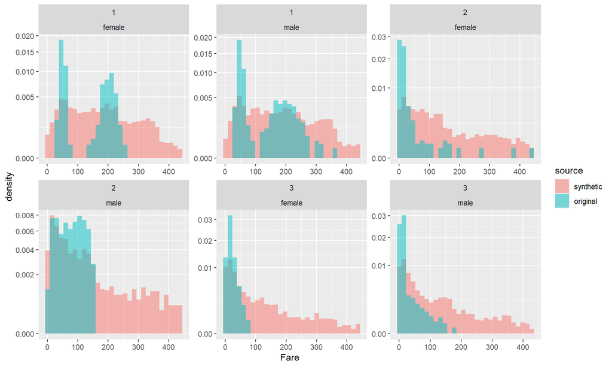

## Experiment 45

- **mtry**: 1
- **family**: unif
- **finite_bounds**: local
- **num_trees**: 500
- **min_node_size**: 100
- **IAE**: 0.879

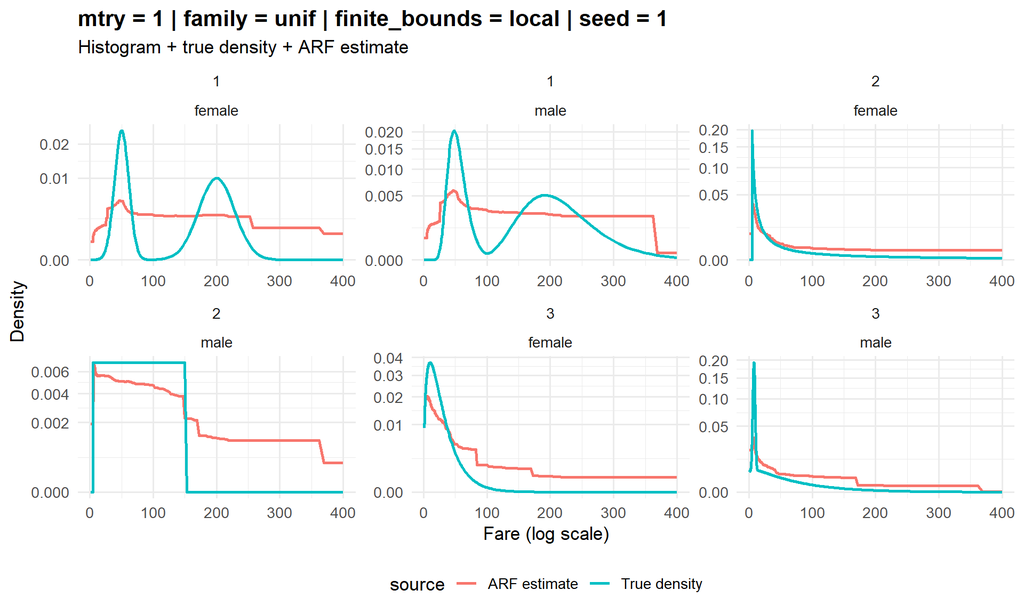

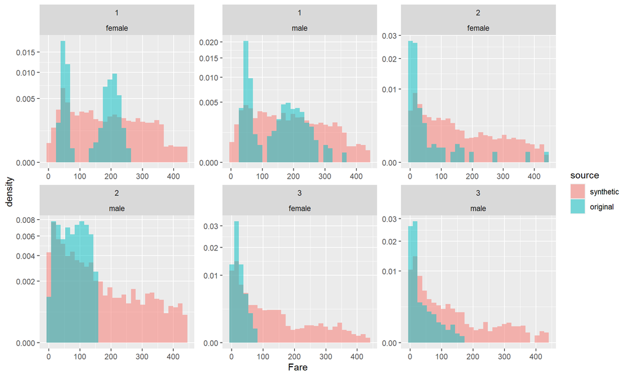

## Experiment 46

- **mtry**: 1
- **family**: unif
- **finite_bounds**: no
- **num_trees**: 500
- **min_node_size**: 100
- **IAE**: 0.879

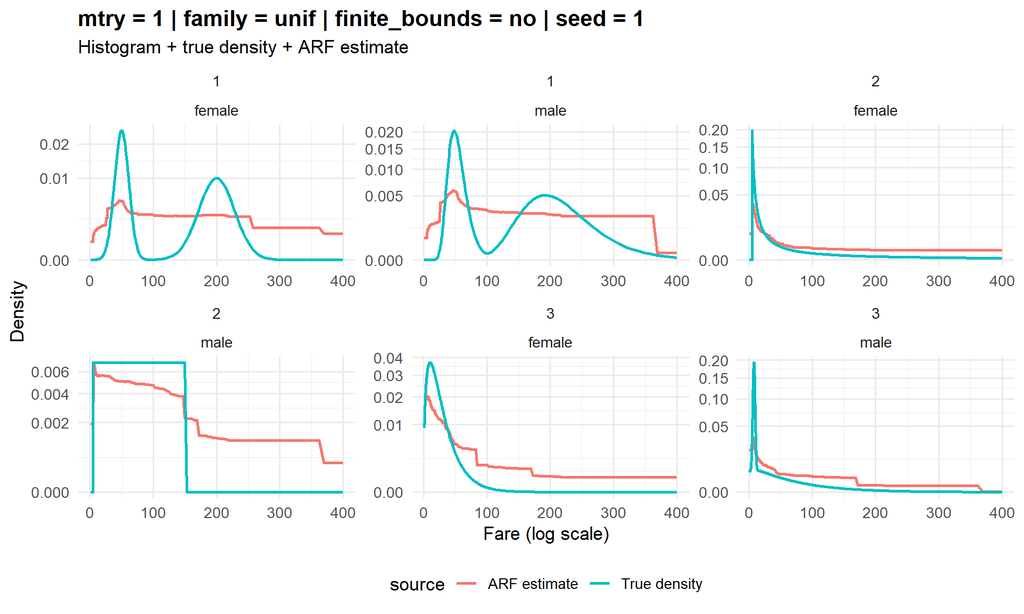

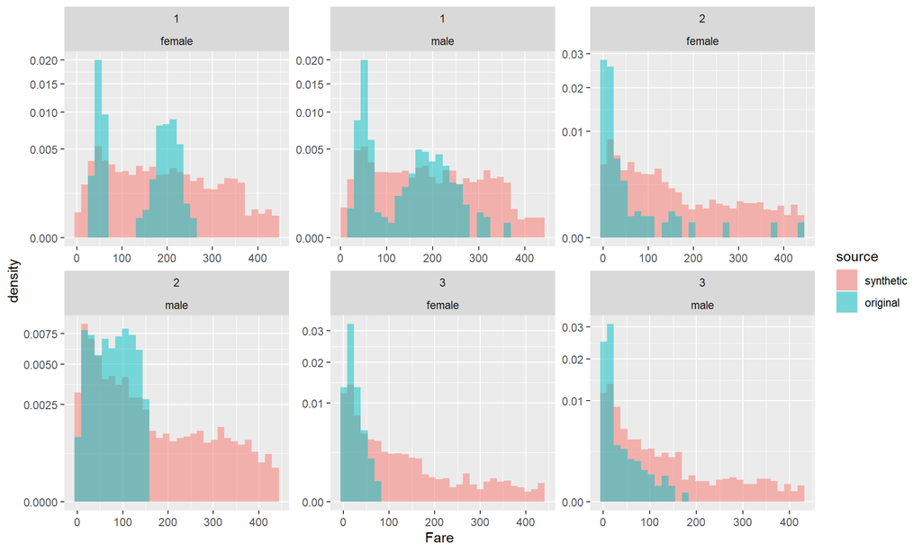

## Experiment 47

- **mtry**: 1
- **family**: unif
- **finite_bounds**: local
- **num_trees**: 100
- **min_node_size**: 20
- **IAE**: 0.988

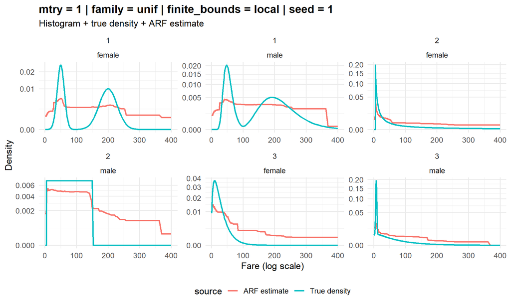

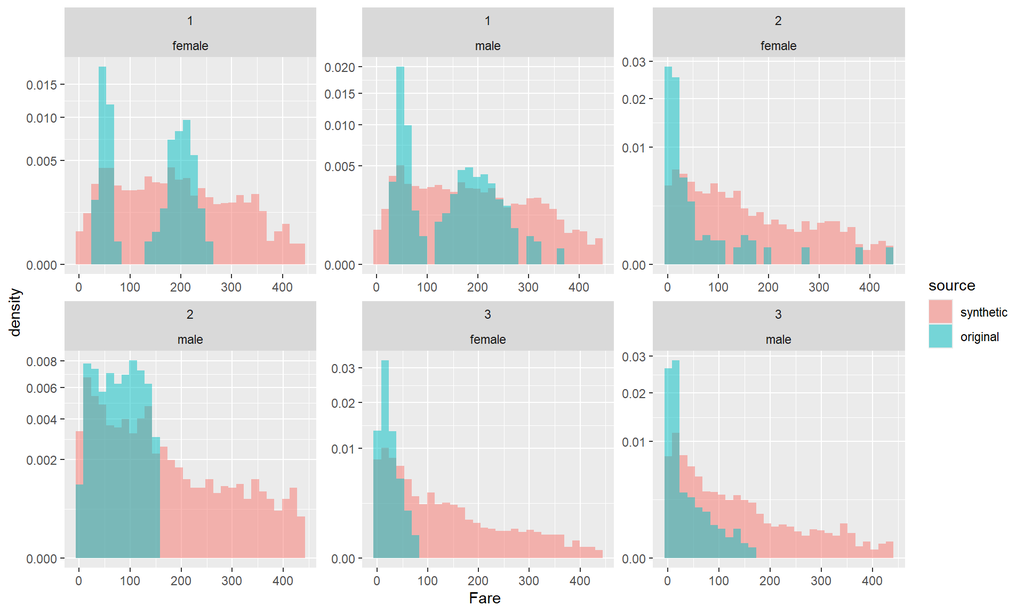

## Experiment 48

- **mtry**: 1
- **family**: unif
- **finite_bounds**: no
- **num_trees**: 100
- **min_node_size**: 20
- **IAE**: 0.988

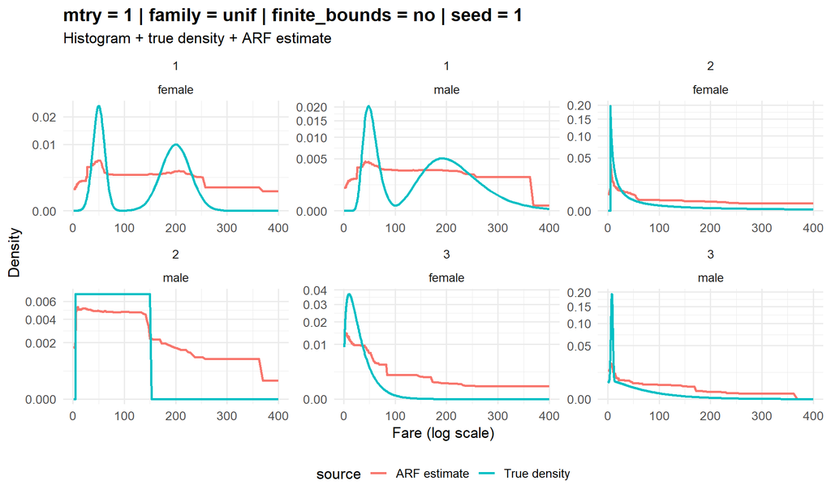

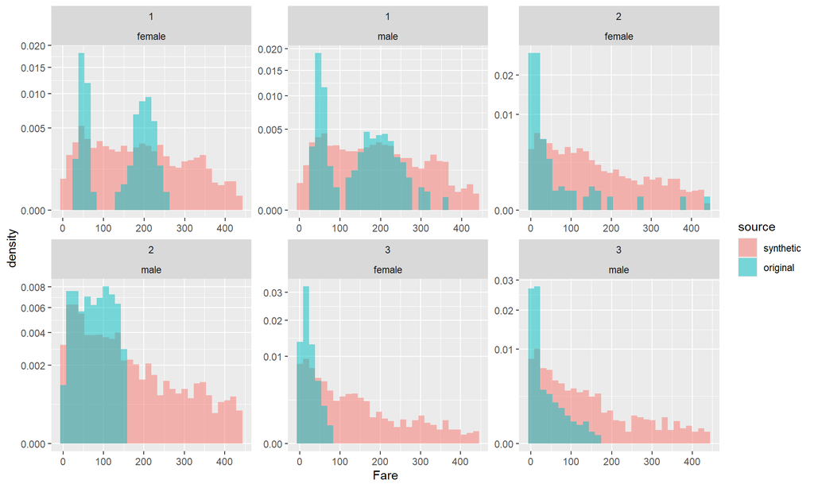